# ML_Assignment_5_Submit

### Machine Learning Assignment 5

## Question 1

A medical claim is denoted by a claim number ('Claim.Number'). Each claim consists of one or more medical lines denoted by a claim line number ('Claim.Line.Number').

1. J-codes are procedure codes that start with the letter 'J'.

   A. Find the number of claim lines that have J-codes.

   B. How much was paid for J-codes to providers for 'in network' claims?

   C. What are the top five J-codes based on the payment to providers?

```python
#import libraries
import pandas as pd
import pandas.io.sql
import pyodbc
import numpy as np
import matplotlib.pyplot as plt
#matplotlib.style.use('ggplot')
%matplotlib inline

import missingno as msno
```

```python
#Reading the data in
claims = pd.read_csv('C:/Users/atsua/OneDrive/Documents/SMU/6. Machine Learning/Assignment 5/claim_sample.csv',delimiter = ',')
claims.tail(5)
```

|  | V1 | Claim_Number | Claim_Line_Number | Member_ID | Provider_ID | Line_Of_Business_ID | Revenue_Code | Service_Code | Place_Of_Service_Code | Procedure_Code | ... | Group_Index | Subscriber_Index | Subgroup_Index | Claim_Type | Claim_Subscriber_Type | Claim_Pre_Prince_Index | Claim_Current_Status | Network_ID | Agreement_ID | paid_unpaid |
| --- | --- | --- | --- | --- | --- | --- | --- | --- | --- | --- | --- | --- | --- | --- | --- | --- | --- | --- | --- | --- | --- |
| 472554 | 79215 | 895587990.0 | 17 | 98799627 | FA0001389001 |  | 636 | OP7O |  |  | ... | 48549 | 80032100 | 52255 | M | H |  | 2 |  |  | 0 |
| 472555 | 79216 | 895587990.0 | 18 | 98799627 | FA0001389001 |  | 636 | OP7O |  |  | ... | 48549 | 80032100 | 52255 | M | H |  | 2 |  |  | 0 |
| 472556 | 79217 | 895587990.0 | 19 | 98799627 | FA0001389001 |  | 260 | IH7O |  |  | ... | 48549 | 80032100 | 52255 | M | H |  | 2 |  |  | 0 |
| 472557 | 103209 | 895587990.0 | 1 | 98799627 | FA0001389001 |  | 324 | RA7O |  | 71020 | ... | 48549 | 80032100 | 52255 | M | H |  | 2 |  |  | 0 |
| 472558 | 27360 | 231056990.0 | 1 | 99975920 | FA0001389001 |  | 324 | RA7O |  | 71020 | ... | 48546 | 80984950 | 0 | M | H |  | 2 |  |  | 0 |

5 rows × 30 columns

```python
claims.shape
```

```
(472559, 30)
```

```python
claims.paid_unpaid.value_counts()
```

```
0    375781
1     96778
Name: paid_unpaid, dtype: int64
```

```python
claims.paid_unpaid = claims.paid_unpaid.astype(np.int64)
```

```python
print (claims.info())
```

```
<class 'pandas.core.frame.DataFrame'>
RangeIndex: 472559 entries, 0 to 472558
Data columns (total 30 columns):
V1                           472559 non-null int64
Claim_Number                 472559 non-null float64
Claim_Line_Number            472559 non-null int64
Member_ID                    472559 non-null int64
Provider_ID                  472559 non-null object
Line_Of_Business_ID          472559 non-null object
Revenue_Code                 472559 non-null object
Service_Code                 472559 non-null object
Place_Of_Service_Code        472559 non-null object
Procedure_Code               472559 non-null object
Diagnosis_Code               472559 non-null object
Claim_Charge_Amount          472559 non-null float64
Denial_Reason_Code           472559 non-null object
Price_Index                  472559 non-null object
In_Out_Of_Network            472559 non-null object
Reference_Index              472559 non-null object
Pricing_Index                472559 non-null object
Capitation_Index             472559 non-null object
Subscriber_Payment_Amount    472559 non-null float64
Provider_Payment_Amount      472559 non-null float64
Group_Index                  472559 non-null int64
Subscriber_Index             472559 non-null int64
Subgroup_Index               472559 non-null int64
Claim_Type                   472559 non-null object
Claim_Subscriber_Type        472559 non-null object
Claim_Pre_Prince_Index       472559 non-null object
Claim_Current_Status         472559 non-null int64
Network_ID                   472559 non-null object
Agreement_ID                 472559 non-null object
paid_unpaid                  472559 non-null int64
dtypes: float64(4), int64(8), object(18)
memory usage: 108.2+ MB
None
```

```python
# Notice that all of the data is stored as a non-null object
# That's not good. It means we need to change those data types
# in order to encode the variables properly. Right now Pandas
# thinks all of our variables are nominal!

import numpy as np
# replace '?' with -1, we will deal with missing values later
#claims = claims.replace(to_replace='?',value=-1)

# let's start by first changing the numeric values to be floats
continuous_features = ['Claim_Charge_Amount', 'Subscriber_Payment_Amount',
                       'Provider_Payment_Amount']

# and the oridnal values to be integers
ordinal_features = ['Claim_Number','Claim_Line_Number','V1',
                    'Member_ID','Group_Index','Subscriber_Index','Subgroup_Index','Claim_Current_Status','paid_unpaid']

# we won't touch these variables, keep them as categorical
categ_features = ['Provider_ID','Line_Of_Business_ID','Revenue_Code','Service_Code','Place_Of_Service_Code',
                 'Procedure_Code','Diagnosis_Code','Denial_Reason_Code','Price_Index',
                 'In_Out_Of_Network','Reference_Index','Pricing_Index','CapitationIndex','Claim_Type',
                 'Claim_Subscriber_Type','Claim_Pre_Prince_Index','Network_ID','Agreement_ID'];

# use the "astype" function to change the variable type
claims[continuous_features] = claims[continuous_features].astype(float)
#claims[continuous_features]
claims[ordinal_features] = claims[ordinal_features].astype(int)

claims.info() # now our data looks better!!
```

```
<class 'pandas.core.frame.DataFrame'>
RangeIndex: 472559 entries, 0 to 472558
Data columns (total 30 columns):
V1                           472559 non-null int32
Claim_Number                 472559 non-null int32
Claim_Line_Number            472559 non-null int32
Member_ID                    472559 non-null int32
Provider_ID                  472559 non-null object
Line_Of_Business_ID          472559 non-null object
Revenue_Code                 472559 non-null object
Service_Code                 472559 non-null object
Place_Of_Service_Code        472559 non-null object
Procedure_Code               472559 non-null object
Diagnosis_Code               472559 non-null object
Claim_Charge_Amount          472559 non-null float64
Denial_Reason_Code           472559 non-null object
Price_Index                  472559 non-null object
In_Out_Of_Network            472559 non-null object
Reference_Index              472559 non-null object
Pricing_Index                472559 non-null object
Capitation_Index             472559 non-null object
Subscriber_Payment_Amount    472559 non-null float64
Provider_Payment_Amount      472559 non-null float64
Group_Index                  472559 non-null int32
Subscriber_Index             472559 non-null int32
Subgroup_Index               472559 non-null int32
Claim_Type                   472559 non-null object
Claim_Subscriber_Type        472559 non-null object
Claim_Pre_Prince_Index       472559 non-null object
Claim_Current_Status         472559 non-null int32
Network_ID                   472559 non-null object
Agreement_ID                 472559 non-null object
paid_unpaid                  472559 non-null int32
dtypes: float64(3), int32(9), object(18)
memory usage: 91.9+ MB
```

```python
# Adding new column for counting
claims['Counter'] = '1'
claims.head(5)
```

|  | V1 | Claim_Number | Claim_Line_Number | Member_ID | Provider_ID | Line_Of_Business_ID | Revenue_Code | Service_Code | Place_Of_Service_Code | Procedure_Code | ... | Subscriber_Index | Subgroup_Index | Claim_Type | Claim_Subscriber_Type | Claim_Pre_Prince_Index | Claim_Current_Status | Network_ID | Agreement_ID | paid_unpaid | Counter |
| --- | --- | --- | --- | --- | --- | --- | --- | --- | --- | --- | --- | --- | --- | --- | --- | --- | --- | --- | --- | --- | --- |
| 0 | 1 | 28849991 | 1 | 9583423 | FA0001411002 | 2 | 128 | RR8I |  |  | ... | 7763000 | 0 | M | H |  | 2 | P00000000002 | FH001310QB01 | 1 | 1 |
| 1 | 2 | 81404290 | 1 | 25210465 | FA0001411002 | 1 | 24 | AL7I |  | A0205 | ... | 20421600 | 0 | M | H |  | 91 | P00000000007 | FH002451QPD1 | 0 | 1 |
| 2 | 3 | 81404290 | 2 | 25210465 | FA0001411002 | 1 | 128 | RR8I |  |  | ... | 20421600 | 0 | M | H |  | 91 | P00000000007 | FH002451QPD1 | 1 | 1 |
| 3 | 4 | 81404290 | 3 | 25210465 | FA0001411002 | 1 | 250 | AL7I |  |  | ... | 20421600 | 0 | M | H |  | 91 | P00000000007 | FH002451QPD1 | 0 | 1 |
| 4 | 5 | 81404290 | 4 | 25210465 | FA0001411002 | 1 | 258 | AL7I |  |  | ... | 20421600 | 0 | M | H |  | 91 | P00000000007 | FH002451QPD1 | 0 | 1 |

5 rows × 31 columns

```python
#Creating For loop to get all Jcode records

booleans = [] #Creating empty list
for length in claims.Procedure_Code:
    if length.startswith('J'):
        booleans.append(True)
    else:
        booleans.append(False)

is_JCode = pd.Series(booleans)
JCode_claims = claims[is_JCode] #Passing boolean object to claims
JCode_claims.head(5)
```

|  | V1 | Claim_Number | Claim_Line_Number | Member_ID | Provider_ID | Line_Of_Business_ID | Revenue_Code | Service_Code | Place_Of_Service_Code | Procedure_Code | ... | Subscriber_Index | Subgroup_Index | Claim_Type | Claim_Subscriber_Type | Claim_Pre_Prince_Index | Claim_Current_Status | Network_ID | Agreement_ID | paid_unpaid | Counter |
| --- | --- | --- | --- | --- | --- | --- | --- | --- | --- | --- | --- | --- | --- | --- | --- | --- | --- | --- | --- | --- | --- |
| 3073 | 3074 | 74645490 | 10 | 1992052 | FA0001389001 | 5 | 636 | OP7O |  | J1650 | ... | 1613650 | 0 | M | H | S | 91 | P00000000001 | FH001309QB01 | 0 | 1 |
| 3091 | 3092 | 18860690 | 8 | 22808129 | FA0001389001 | 1 | 636 | OP7O |  | J2405 | ... | 18475600 | 483 | M | H |  | 2 | H00000000001 | FH001886QH01 | 0 | 1 |
| 3092 | 3093 | 18860690 | 9 | 22808129 | FA0001389001 | 1 | 636 | OP7O |  | J7030 | ... | 18475600 | 483 | M | H |  | 2 | H00000000001 | FH001886QH01 | 0 | 1 |
| 3103 | 3104 | 281757390 | 10 | 1997607 | FA0001389001 | 5 | 636 | OP7O |  | J1650 | ... | 1618150 | 0 | M | H | S | 91 | P00000000001 | FH001309QB01 | 0 | 1 |
| 3114 | 3115 | 450273590 | 10 | 1991496 | FA0001389001 | 5 | 636 | OP7O |  | J1650 | ... | 1613200 | 0 | M | H | S | 2 | P00000000001 | FH001309QB01 | 0 | 1 |

5 rows × 31 columns

```python
JCode_claims.shape
```

```
(51029, 31)
```

```python
print (JCode_claims.info())
```

```
<class 'pandas.core.frame.DataFrame'>
Int64Index: 51029 entries, 3073 to 472463
Data columns (total 31 columns):
V1                           51029 non-null int32
Claim_Number                 51029 non-null int32
Claim_Line_Number            51029 non-null int32
Member_ID                    51029 non-null int32
Provider_ID                  51029 non-null object
Line_Of_Business_ID          51029 non-null object
Revenue_Code                 51029 non-null object
Service_Code                 51029 non-null object
Place_Of_Service_Code        51029 non-null object
Procedure_Code               51029 non-null object
Diagnosis_Code               51029 non-null object
Claim_Charge_Amount          51029 non-null float64
Denial_Reason_Code           51029 non-null object
Price_Index                  51029 non-null object
In_Out_Of_Network            51029 non-null object
Reference_Index              51029 non-null object
Pricing_Index                51029 non-null object
Capitation_Index             51029 non-null object
Subscriber_Payment_Amount    51029 non-null float64
Provider_Payment_Amount      51029 non-null float64
Group_Index                  51029 non-null int32
Subscriber_Index             51029 non-null int32
Subgroup_Index               51029 non-null int32
Claim_Type                   51029 non-null object
Claim_Subscriber_Type        51029 non-null object
Claim_Pre_Prince_Index       51029 non-null object
Claim_Current_Status         51029 non-null int32
Network_ID                   51029 non-null object
Agreement_ID                 51029 non-null object
paid_unpaid                  51029 non-null int32
Counter                      51029 non-null object
dtypes: float64(3), int32(9), object(19)
memory usage: 10.7+ MB
None
```

```python
JCode_claims.Counter.value_counts()
```

```
1    51029
Name: Counter, dtype: int64
```

### Question 1.A

```python
print("The number of codes that have J-codes are: %.2f"
      % JCode_claims.Counter.value_counts())
```

```
The number of codes that have J-codes are: 51029.00
```

### Question 1.B

```
B. How much was paid for J-codes to providers for 'in network' claims?
```

```python
JJ2 = JCode_claims[JCode_claims["In_Out_Of_Network"]=='I']
#JJ2.head(5)
JJ = JJ2['Claim_Charge_Amount'].sum()
JJ
```

```
9574776.83
```

### Question 1.C

```
C. What are the top five J-codes based on the payment to providers?
```

```python
A = JCode_claims.pivot_table(index="Procedure_Code",values = "Provider_Payment_Amount", aggfunc = "sum")#,columns = "Provider_Payment_Amount")#, aggfunc = "avg")
```

```python
AB = A.sort_values(by = 'Provider_Payment_Amount',ascending=False )
AB.head(5)
```

| Procedure_Code | Provider_Payment_Amount |
| --- | --- |
| J1745 | 434232.09 |
| J0180 | 299776.51 |
| J9310 | 168630.88 |
| J3490 | 90249.84 |
| J1644 | 81909.37 |

### Question 2

1. For the following exercises, determine the number of providers that were paid for at least one J-code. Use the J-code claims for these providers to complete the following exercises.

   A. Create a scatter plot that displays the number of unpaid claims (lines where the ‘Provider.Payment.Amount’ field is equal to zero) for each provider versus the number of paid claims.

   B. What insights can you suggest from the graph?

   C. Based on the graph, is the behavior of any of the providers concerning? Explain.

```
Text(0,0.5,'Number of Claims')
```

[figure not shown]

```python
#Creating a scatter plot of our x data
plt.scatter(JCode_claims.Provider_ID,JCode_claims.Provider_Payment_Amount)
plt.title('Scatter Plot of claims data')
plt.xlabel('Provider')
plt.ylabel('Number of Claims')
```

### C. Based on the graph, is the behavior of any of the providers concerning? Explain.

From this chart, we can determine that there is one provider that seems to be having a couple of unusual charges. The chart shows that there are some outliers(charges) that should be of concern to us.

### Question 3

```
3. Consider all claim lines with a J-code.

     A. What percentage of J-code claim lines were unpaid?

     B. Create a model to predict when a J-code is unpaid. Explain why you choose the modeling approach.

     C. How accurate is your model at predicting unpaid claims?

      D. What data attributes are predominately influencing the rate of non-payment?
```

#### A. What percentage of J-code claim lines were unpaid?

```python
# the percentage of J-Codes that were unpaid
len(JCode_claims[JCode_claims.Provider_Payment_Amount==0])/len(JCode_claims)*100.0
```

```
88.1087224911325
```

#### B. Create a model to predict when a J-code is unpaid. Explain why you choose the modeling approach.

#### Selecting only certain records for our model

```python
#Bringing in the data through SQL
# Parameters
server = 'LAPTOP-ATSU\SQLEXPRESS'
db = 'Machine_Learning'

# Create the connection
conn = pyodbc.connect('driver={ODBC Driver 13 for SQL Server};SERVER=' + server + ';DATABASE=' + db + ';Trusted_Connection=yes')

# query db
sql = """
/****** Script for SelectTopNRows command from SSMS  ******/
SELECT [V1]
      --,[Claim_Number]
      ,[Claim_Line_Number]
      --,[Member_ID]
      --,[Provider_ID]
      --,[Line_Of_Business_ID]
      --,[Revenue_Code]
      --,[Service_Code]
      --,[Place_Of_Service_Code]
      --,[Procedure_Code]
      --,[Diagnosis_Code]
      ,[Claim_Charge_Amount]
      --,[Denial_Reason_Code]
      --,[Price_Index]
      ,[In_Out_Of_Network]
      --,[Reference_Index]
      --,[Pricing_Index]
      --,[Capitation_Index]
      ,[Subscriber_Payment_Amount]
      ,[Provider_Payment_Amount]
      --,[Group_Index]
      --,[Subscriber_Index]
      --,[Subgroup_Index]
      --,[Claim_Type]
      --,[Claim_Subscriber_Type]
      --,[Claim_Pre_Prince_Index]
      --,[Claim_Current_Status]
      --,[Network_ID]
      --,[Agreement_ID]
      ,Case
      When
      convert(float,Provider_Payment_Amount) > 0.0 then 1
      else 0
      end as paid_unpaid

  FROM [Machine_Learning].[dbo].[claim_sample]
  where Procedure_Code like '%J%'

"""
paid_unpaid_claims = pandas.io.sql.read_sql(sql, conn)
paid_unpaid_claims.head()
```

|  | V1 | Claim_Line_Number | Claim_Charge_Amount | In_Out_Of_Network | Subscriber_Payment_Amount | Provider_Payment_Amount | paid_unpaid |
| --- | --- | --- | --- | --- | --- | --- | --- |
| 0 | 51775 | 5 | 672.567945 | I | 0 | 0 | 0 |
| 1 | 51776 | 9 | 78.477165 | I | 0 | 0 | 0 |
| 2 | 51777 | 6 | 442.74108 | I | 0 | 0 | 0 |
| 3 | 51778 | 7 | 104.9325 | I | 0 | 0 | 0 |
| 4 | 51779 | 8 | 118.83297 | I | 0 | 0 | 0 |

```python
#One hot encoding the In_Out_Network
tmp_df = pd.get_dummies(paid_unpaid_claims.In_Out_Of_Network,prefix='In_Out_Of_Network')
paid_unpaid_claims = pd.concat((paid_unpaid_claims,tmp_df),axis=1) # add back into the dataframe
```

```python
if 'In_Out_Of_Network_' in paid_unpaid_claims:
    del paid_unpaid_claims['In_Out_Of_Network_'] # get reid of the original category as it is now one-hot encoded
```

```python
paid_unpaid_claims.head(5)
```

|  | V1 | Claim_Line_Number | Claim_Charge_Amount | Subscriber_Payment_Amount | Provider_Payment_Amount | paid_unpaid | In_Out_Of_Network_ | In_Out_Of_Network_I | In_Out_Of_Network_O |
| --- | --- | --- | --- | --- | --- | --- | --- | --- | --- |
| 0 | 51775 | 5 | 672.567945 | 0.0 | 0.0 | 0 | 0 | 1 | 0 |
| 1 | 51776 | 9 | 78.477165 | 0.0 | 0.0 | 0 | 0 | 1 | 0 |
| 2 | 51777 | 6 | 442.741080 | 0.0 | 0.0 | 0 | 0 | 1 | 0 |
| 3 | 51778 | 7 | 104.932500 | 0.0 | 0.0 | 0 | 0 | 1 | 0 |
| 4 | 51779 | 8 | 118.832970 | 0.0 | 0.0 | 0 | 0 | 1 | 0 |

```python
paid_unpaid_claims.info()
```

```
<class 'pandas.core.frame.DataFrame'>
RangeIndex: 153823 entries, 0 to 153822
Data columns (total 9 columns):
V1                           153823 non-null int64
Claim_Line_Number            153823 non-null int64
Claim_Charge_Amount          153823 non-null float64
Subscriber_Payment_Amount    153823 non-null float64
Provider_Payment_Amount      153823 non-null float64
paid_unpaid                  153823 non-null int64
In_Out_Of_Network_           153823 non-null uint8
In_Out_Of_Network_I          153823 non-null uint8
In_Out_Of_Network_O          153823 non-null uint8
dtypes: float64(3), int64(3), uint8(3)
memory usage: 7.5 MB
```

```python
#previewing the data
paid_unpaid_claims.paid_unpaid.value_counts()
```

```
0    134980
1     18843
Name: paid_unpaid, dtype: int64
```

```python
paid_unpaid_claims['Provider_Payment_Amount'] = paid_unpaid_claims.Provider_Payment_Amount.convert_objects(convert_numeric=True)
paid_unpaid_claims['paid_unpaid'] = paid_unpaid_claims.paid_unpaid.convert_objects(convert_numeric=True)
paid_unpaid_claims['V1'] = paid_unpaid_claims.V1.convert_objects(convert_numeric=True)
paid_unpaid_claims['Claim_Charge_Amount'] = paid_unpaid_claims.Claim_Charge_Amount.convert_objects(convert_numeric=True)
paid_unpaid_claims['Claim_Line_Number'] = paid_unpaid_claims.Claim_Line_Number.convert_objects(convert_numeric=True)
paid_unpaid_claims['V1'] = paid_unpaid_claims.V1.convert_objects(convert_numeric=True)
paid_unpaid_claims['Subscriber_Payment_Amount'] = paid_unpaid_claims.Subscriber_Payment_Amount.convert_objects(convert_numeric=True)
#paid_unpaid_claims['Claim_Charge_Amount'] = paid_unpaid_claims.Provider_Payment_Amount.convert_objects(convert_numeric=True)
```

```python
paid_unpaid_claims.paid_unpaid = paid_unpaid_claims.paid_unpaid.astype(np.int64)
paid_unpaid_claims.Claim_Line_Number = paid_unpaid_claims.Claim_Line_Number.astype(np.int64)
paid_unpaid_claims.V1 = paid_unpaid_claims.V1.astype(np.int64)
```

```python
paid_unpaid_claims.info()
```

```
<class 'pandas.core.frame.DataFrame'>
RangeIndex: 153823 entries, 0 to 153822
Data columns (total 9 columns):
V1                           153823 non-null int64
Claim_Line_Number            153823 non-null int64
Claim_Charge_Amount          153823 non-null float64
Subscriber_Payment_Amount    153823 non-null float64
Provider_Payment_Amount      153823 non-null float64
paid_unpaid                  153823 non-null int64
In_Out_Of_Network_           153823 non-null uint8
In_Out_Of_Network_I          153823 non-null uint8
In_Out_Of_Network_O          153823 non-null uint8
dtypes: float64(3), int64(3), uint8(3)
memory usage: 7.5 MB
```

```python
from sklearn.model_selection import ShuffleSplit

# we want to predict the X and y data as follows:
if 'paid_unpaid' in paid_unpaid_claims:
    y = paid_unpaid_claims['paid_unpaid'].values # get the labels we want
    del paid_unpaid_claims['paid_unpaid'] # get rid of the class label
    X = paid_unpaid_claims.values # use everything else to predict!

    ## X and y are now numpy matrices, by calling 'values' on the pandas data frames we
    #    have converted them into simple matrices to use with scikit learn


# to use the cross validation object in scikit learn, we need to grab an instance
#    of the object and set it up. This object will be able to split our data into
#    training and testing splits
num_cv_iterations = 3
num_instances = len(y)
cv_object = ShuffleSplit(n_splits=num_cv_iterations,
                         test_size  = 0.2)

print(cv_object)
```

```
ShuffleSplit(n_splits=3, random_state=None, test_size=0.2, train_size=None)
```

# Logistic Regression

Now let's use Logistic Regression from `scikit-learn`. The documentation can be found here:

http://scikit-learn.org/stable/modules/generated/sklearn.linear_model.LogisticRegression.html

```python
# run logistic regression and vary some parameters
from sklearn.linear_model import LogisticRegression
from sklearn import metrics as mt

# first we create a reusable logisitic regression object
#   here we can setup the object with different learning parameters and constants
lr_clf = LogisticRegression(penalty='l2', C=1.0, class_weight='balanced') # get object

# now we can use the cv_object that we setup before to iterate through the
#    different training and testing sets. Each time we will reuse the logisitic regression
#    object, but it gets trained on different data each time we use it.

iter_num=0
# the indices are the rows used for training and testing in each iteration
for train_indices, test_indices in cv_object.split(X,y):
    # I will create new variables here so that it is more obvious what
    # the code is doing (you can compact this syntax and avoid duplicating memory,
    # but it makes this code less readable)
    X_train = X[train_indices]
    y_train = y[train_indices]

    X_test = X[test_indices]
    y_test = y[test_indices]

    # train the reusable logisitc regression model on the training data
    lr_clf.fit(X_train,y_train)  # train object
    y_hat = lr_clf.predict(X_test) # get test set precitions

    # now let's get the accuracy and confusion matrix for this iterations of training/testing
    acc = mt.accuracy_score(y_test,y_hat)
    conf = mt.confusion_matrix(y_test,y_hat)
    print("====Iteration",iter_num," ====")
    print("accuracy", acc )
    print("confusion matrix\n",conf)
    iter_num+=1

# Also note that every time you run the above code
#   it randomly creates a new training and testing set,
#   so accuracy will be different each time
```

```
====Iteration 0  ====
accuracy 0.996977084349098
confusion matrix
 [[27000    10]
 [   83  3672]]
====Iteration 1  ====
accuracy 0.9951243295953194
confusion matrix
 [[26979     7]
 [  143  3636]]
====Iteration 2  ====
accuracy 0.9957744189826101
confusion matrix
 [[26893     5]
 [  125  3742]]
```

```python
# this does the exact same thing as the above block of code, but with shorter syntax

for iter_num, (train_indices, test_indices) in enumerate(cv_object.split(X,y)):
    lr_clf.fit(X[train_indices],y[train_indices])  # train object
    y_hat = lr_clf.predict(X[test_indices]) # get test set precitions

    # print the accuracy and confusion matrix
    print("====Iteration",iter_num," ====")
    print("accuracy", mt.accuracy_score(y[test_indices],y_hat))
    print("confusion matrix\n",mt.confusion_matrix(y[test_indices],y_hat))
```

```
====Iteration 0  ====
accuracy 0.9964570128392654
confusion matrix
 [[27164     6]
 [  103  3492]]
====Iteration 1  ====
accuracy 0.996554526247359
confusion matrix
 [[26970     4]
 [  102  3689]]
====Iteration 2  ====
accuracy 0.9965220217779944
confusion matrix
 [[27019     9]
 [   98  3639]]
```

```python
# and here is an even shorter way of getting the accuracies for each training and test set
from sklearn.model_selection import cross_val_score
accuracies = cross_val_score(lr_clf, X, y=y, cv=cv_object) # this also can help with parallelism
print(accuracies)
```

```
[0.99616447 0.99726962 0.99645701]
```

## Interpretting weights

The weights gives us an idea as to how the variables influence the models.

```python
# interpret the weights

# iterate over the coefficients
weights = lr_clf.coef_.T # take transpose to make a column vector
variable_names = paid_unpaid_claims.columns
for coef, name in zip(weights,variable_names):
    print(name, 'has weight of', coef[0])

# does this look correct?
```

[output not shown]

These weight interpretations **are not neccessarily interpretable** because of the values we had. Very large attribute values could just as easily be assigned a higher weight. Instead, let's normalize the feature values so that all the attributes are on the same dynamic range. Once we normalize the attributes, the weights should have magnitudes that reflect their poredictive power in the logistic regression model.

```python
from sklearn.preprocessing import StandardScaler

# we want to normalize the features based upon the mean and standard deviation of each column.
# However, we do not want to accidentally use the testing data to find out the mean and std (this would be snooping)
# to Make things easier, let's start by just using whatever was last stored in the variables:
##    X_train , y_train , X_test, y_test (they were set in a for loop above)

# scale attributes by the training set
scl_obj = StandardScaler()
scl_obj.fit(X_train) # find scalings for each column that make this zero mean and unit std
# the line of code above only looks at training data to get mean and std and we can use it
# to transform new feature data

X_train_scaled = scl_obj.transform(X_train) # apply to training
X_test_scaled = scl_obj.transform(X_test) # apply those means and std to the test set (without snooping at the test set values)

# train the model just as before
lr_clf = LogisticRegression(penalty='l2', C=0.05) # get object, the 'C' value is less (can you guess why??)
lr_clf.fit(X_train_scaled,y_train)  # train object

y_hat = lr_clf.predict(X_test_scaled) # get test set precitions

acc = mt.accuracy_score(y_test,y_hat)
conf = mt.confusion_matrix(y_test,y_hat)
print('accuracy:', acc )
print(conf )

# sort these attributes and spit them out
zip_vars = zip(lr_clf.coef_.T,paid_unpaid_claims.columns) # combine attributes
zip_vars = sorted(zip_vars)
for coef, name in zip_vars:
    print(name, 'has weight of', coef[0]) # now print them out
```

```
accuracy: 0.952478465789046
[[26898     0]
 [ 1462  2405]]
Claim_Charge_Amount has weight of -3.045106480088529
In_Out_Of_Network_  has weight of -1.182184937133987
Subscriber_Payment_Amount has weight of -0.027277136934931265
Claim_Line_Number has weight of 0.07762816464322468
V1 has weight of 0.19885751654359138
In_Out_Of_Network_O has weight of 0.23961323322857167
In_Out_Of_Network_I has weight of 1.1488517021315612
Provider_Payment_Amount has weight of 20.974994818473494
```

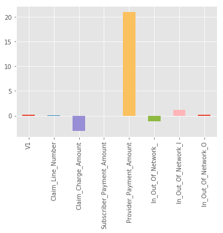

```python
# now let's make a pandas Series with the names and values, and plot them
from matplotlib import pyplot as plt
%matplotlib inline
plt.style.use('ggplot')


weights = pd.Series(lr_clf.coef_[0],index=paid_unpaid_claims.columns)
weights.plot(kind='bar')
plt.show()
```

```python
from sklearn.preprocessing import StandardScaler
# we want to normalize the features based upon the mean and standard deviation of each column.
# However, we do not want to accidentally use the testing data to find out the mean and std (this would be snooping)

from sklearn.pipeline import Pipeline
# you can apply the StandardScaler function inside of the cross-validation loop
#  but this requires the use of PipeLines in scikit.
#  A pipeline can apply feature pre-processing and data fitting in one compact notation
#  Here is an example!

std_scl = StandardScaler()
lr_clf = LogisticRegression(penalty='l2', C=0.05)

# create the pipline
piped_object = Pipeline([('scale', std_scl),  # do this
                         ('logit_model', lr_clf)]) # and then do this

weights = []
# run the pipline cross validated
for iter_num, (train_indices, test_indices) in enumerate(cv_object.split(X,y)):
    piped_object.fit(X[train_indices],y[train_indices])  # train object
    # it is a little odd getting trained objects from a  pipeline:
    weights.append(piped_object.named_steps['logit_model'].coef_[0])


weights = np.array(weights)
```

```python
import plotly
plotly.offline.init_notebook_mode() # run at the start of every notebook

error_y=dict(
            type='data',
            array=np.std(weights,axis=0),
            visible=True
        )

graph1 = {'x': paid_unpaid_claims.columns,
          'y': np.mean(weights,axis=0),
    'error_y':error_y,
       'type': 'bar'}

fig = dict()
fig['data'] = [graph1]
fig['layout'] = {'title': 'Logistic Regression Weights, with error bars'}

plotly.offline.iplot(fig)
```

[interactive chart not shown]

**For more improvement and guarding against overfitting:** At this point it would make sense to remove variables that are highly related to one another or ones that are irrelevant and keep going with the weights analysis.

```python
Xnew = paid_unpaid_claims[['Claim_Charge_Amount','Subscriber_Payment_Amount','Provider_Payment_Amount']].values

weights = []
# run the pipline corssvalidated
for iter_num, (train_indices, test_indices) in enumerate(cv_object.split(Xnew,y)):
    piped_object.fit(Xnew[train_indices],y[train_indices])  # train object
    weights.append(piped_object.named_steps['logit_model'].coef_[0])

weights = np.array(weights)

error_y=dict(
            type='data',
            array=np.std(weights,axis=0),
            visible=True
        )

graph1 = {'x': ['Claim_Charge_Amount','Subscriber_Payment_Amount','Provider_Payment_Amount'],
          'y': np.mean(weights,axis=0),
    'error_y':error_y,
       'type': 'bar'}

fig = dict()
fig['data'] = [graph1]
fig['layout'] = {'title': 'Logistic Regression Weights, with error bars'}

plotly.offline.iplot(fig)
```

[interactive chart not shown]